# 6. Otsu Thresholding

## 3.1 Aplicación a imágenes propias (trabajo del equipo)

```python
# Helpers: load a gray image from the repo data folder

import cv2
import numpy as np
from pathlib import Path

DATA = Path("../../data/semana9")

def load_gray(name, size=None):
    img = cv2.imread(str(DATA / name), cv2.IMREAD_GRAYSCALE)
    if img is None:
        raise FileNotFoundError(name)
    if size is not None:
        img = cv2.resize(img, size)
    return img

def otsu_score(img, thresh):
    """Otsu separability measure n = sigmaB^2 / sigmaG^2 (scale-free).

    Computed directly from the histogram, as in the course slides (5.2).
    Higher n => classes are better separated => easier segmentation.
    """
    hist, _ = np.histogram(img, bins=256, range=(0, 256))
    p = hist / hist.sum()
    values = np.arange(256)
    mG = float(np.sum(values * p))
    w0 = np.cumsum(p)
    m0 = np.cumsum(values * p)
    w1 = 1.0 - w0
    m1 = mG - m0
    w0 = np.where(w0 == 0, 1e-12, w0)
    w1 = np.where(w1 == 0, 1e-12, w1)
    m0 = m0 / w0
    m1 = m1 / w1
    sigmaB2 = w0 * w1 * (m0 - m1) ** 2
    sigmaG2 = float(np.sum((values - mG) ** 2 * p))
    k = int(round(thresh))
    k = min(max(k, 0), 254)
    return float(sigmaB2[k] / sigmaG2)

print("Helpers listos.")
```

```
Helpers listos.
```

## 4. Experimentos propios: umbral fijo vs Otsu

Con tres imágenes de dominio (fábrica, tablero, casa) comparamos un **umbral fijo global** contra **Otsu**. La misma imagen, mismo criterio de visualización, distinto umbral.

- `factory_a.jpg` — escena industrial, iluminación mixta.
- `chessboard_c.jpg` — tablero de ajedrez (patrones de alto contraste).
- `house_1.jpg` — fachada residencial con cielo (múltiples niveles de intensidad).

```
factory: fixed=127, otsu=105.00
```

```
chessboard: fixed=127, otsu=105.00
house: fixed=127, otsu=119.00
```

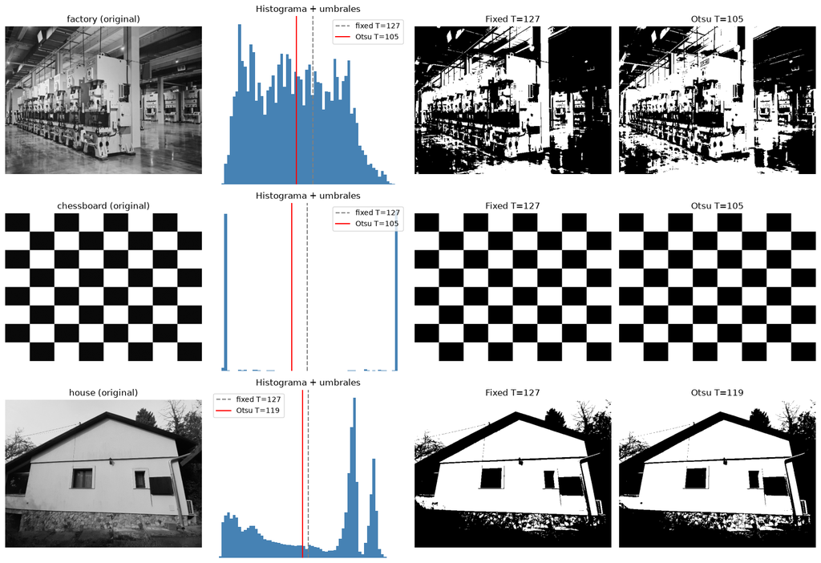

```python
# Umbral fijo (T=127) vs Otsu sobre las tres imágenes

images = {
    "factory": load_gray("factory_a.jpg", (640, 480)),
    "chessboard": load_gray("chessboard_c.jpg", (640, 480)),
    "house": load_gray("house_1.jpg", (640, 480)),
}

FIXED_T = 127

fig, axes = plt.subplots(3, 4, figsize=(16, 11))
for row, (name, img) in enumerate(images.items()):
    t_otsu = threshold_otsu(img)
    axes[row, 0].imshow(img, cmap="gray");          axes[row, 0].set_title(f"{name} (original)")
    axes[row, 1].hist(img.ravel(), bins=64, color="steelblue")
    axes[row, 1].axvline(FIXED_T, color="gray", ls="--", label=f"fixed T={FIXED_T}")
    axes[row, 1].axvline(t_otsu, color="red", label=f"Otsu T={t_otsu:.0f}")
    axes[row, 1].set_title("Histograma + umbrales"); axes[row, 1].legend()
    axes[row, 2].imshow(img > FIXED_T, cmap="gray"); axes[row, 2].set_title(f"Fixed T={FIXED_T}")
    axes[row, 3].imshow(img > t_otsu, cmap="gray");  axes[row, 3].set_title(f"Otsu T={t_otsu:.0f}")
    print(f"{name}: fixed={FIXED_T}, otsu={t_otsu:.2f}")
for ax in axes.ravel():
    ax.axis("off")
plt.tight_layout()
plt.show()
```

## 5. Métrica de separabilidad de Otsu $n = \sigma_B^2 / \sigma_G^2$

De las diapositivas de la semana: la varianza inter-clase $\sigma_B^2$ mide qué tan bien separadas están las dos clases, y $\sigma_G^2$ (varianza global) la normaliza. El resultado es una **medida adimensional de separabilidad**: a mayor $n$, más fácil de segmentar es la imagen con un umbral único. La calculamos directamente del histograma para cada imagen y umbral.

```python
# Separability score per image and per threshold

print(f"{'image':<12} {'T fijo':>8} {'n (fijo)':>10} {'T Otsu':>8} {'n (Otsu)':>10}")
print("-" * 52)
for name, img in images.items():
    t_otsu = threshold_otsu(img)
    n_fixed = otsu_score(img, FIXED_T)
    n_otsu = otsu_score(img, t_otsu)
    print(f"{name:<12} {FIXED_T:>8} {n_fixed:>10.4f} {t_otsu:>8.2f} {n_otsu:>10.4f}")
```

```
image          T fijo   n (fijo)   T Otsu   n (Otsu)
----------------------------------------------------
factory           127     0.6867   105.00     0.7347
chessboard        127     0.9935   105.00     0.9935
house             127     0.8675   119.00     0.8697
```

## 6. Iluminación no uniforme + Otsu por ventanas (requisito opcional)

Construimos el caso límite del single thresholding: una **hoja de texto bajo iluminación no uniforme** (degradado multiplicativo simulado sobre `data.page()`).

1. **Global fixed** — umbral fijo en la imagen degradada.
2. **Global Otsu** — el histograma bimodal se ensancha/desdobra y el umbral "óptimo" ya no segmenta bien toda la hoja.
3. **Otsu por ventanas (adaptativo)** — la imagen se divide en bloques y cada bloque usa *su propio* umbral de Otsu. Esto es el mismo principio de `cv2.threshold(..., THRESH_OTSU)` aplicado localmente; es un paso hacia `THRESH_BINARY` con `GaussianBlur`/`adaptiveThreshold`.

Conclusión esperada: cuando la iluminación cambia a lo largo de la imagen, **ningún umbral global** (fijo ni Otsu) segmenta bien; el Otsu local (por bloques) recupera el texto en zonas oscuras y brillantes a la vez.

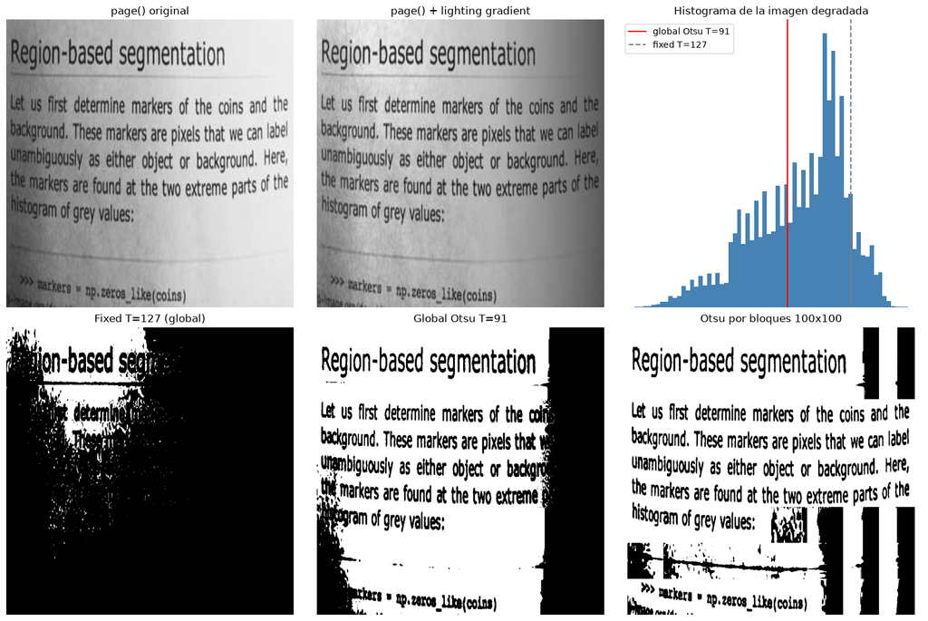

```
Separabilidad n: fixed=0.2200  global Otsu=0.7065
(n alto en global Otsu no garantiza buena segmentación visual cuando la iluminación no es uniforme)
```

```python
# Case A: sheet of paper with a simulated lighting gradient

page = data.page()                     # (200, 200) grayscale
page_big = cv2.resize(page, (800, 800))

# Multiplicative lighting gradient: bright on the left, dark on the right
x = np.linspace(1.0, 0.25, 800)
lighting = np.tile(x, (800, 1))
lit_page = np.clip(page_big * lighting, 0, 255).astype(np.uint8)

# Case B: block-wise (adaptive) Otsu
def block_otsu(img, block=(64, 64)):
    h, w = img.shape
    bh, bw = block
    out = np.zeros_like(img)
    for y in range(0, h, bh):
        for xx in range(0, w, bw):
            patch = img[y:y+bh, xx:xx+bw]
            if patch.size == 0:
                continue
            t = threshold_otsu(patch)
            out[y:y+bh, xx:xx+bw] = patch > t
    return out

block_mask = block_otsu(lit_page, block=(100, 100))

fig, axes = plt.subplots(2, 3, figsize=(15, 10))
axes[0, 0].imshow(page_big, cmap="gray");            axes[0, 0].set_title("page() original")
axes[0, 1].imshow(lit_page, cmap="gray");            axes[0, 1].set_title("page() + lighting gradient")
axes[0, 2].hist(lit_page.ravel(), bins=64, color="steelblue")
t_lit = threshold_otsu(lit_page)
axes[0, 2].axvline(t_lit, color="red", label=f"global Otsu T={t_lit:.0f}")
axes[0, 2].axvline(FIXED_T, color="gray", ls="--", label=f"fixed T={FIXED_T}")
axes[0, 2].legend(); axes[0, 2].set_title("Histograma de la imagen degradada")
axes[1, 0].imshow(lit_page > FIXED_T, cmap="gray");  axes[1, 0].set_title(f"Fixed T={FIXED_T} (global)")
axes[1, 1].imshow(lit_page > t_lit, cmap="gray");    axes[1, 1].set_title(f"Global Otsu T={t_lit:.0f}")
axes[1, 2].imshow(block_mask, cmap="gray");          axes[1, 2].set_title("Otsu por bloques 100x100")
for ax in axes.ravel():
    ax.axis("off")
plt.tight_layout()
plt.show()

n_fixed = otsu_score(lit_page, FIXED_T)
n_otsu  = otsu_score(lit_page, t_lit)
print(f"Separabilidad n: fixed={n_fixed:.4f}  global Otsu={n_otsu:.4f}")
print("(n alto en global Otsu no garantiza buena segmentación visual cuando la iluminación no es uniforme)")
```

## 7. Discusión de resultados

### Fortalezas

- **Automático y barato**: solo necesita el histograma (array 1D) y un barrido de 256 umbrales.
- **Óptimo bajo su criterio**: si el histograma es bimodal y las clases son gaussianas, coincide con la regla de Bayes de máxima verosimilitud.
- **Reproducible**: misma imagen, mismo umbral, sin parámetros que ajustar.

### Debilidades (lo que muestran los experimentos)

1. **Asume bimodalidad**. Si el histograma no tiene dos picos claros (o tiene más de dos), el umbral "óptimo" no corresponde a una separación semántica de la imagen.
2. **Falla con iluminación no uniforme**: el caso de la hoja con degradado muestra que un mismo objeto (el texto) proyecta intensidades distintas en la imagen, el histograma global se ensancha y el umbral único — fijo o de Otsu — deja zonas completas mal segmentadas.
3. **No es semántico**: agrupa por intensidad, no por objeto. Dos objetos del mismo tono se fusionan; un objeto de tonos variados se fragmenta.
4. **Sensible a ruido**: el ruido gaussiano agrega masa al valle del histograma y desplaza el umbral (se mitiga suavizando antes).

### Single thresholding vs Otsu

Un umbral fijo es arbitrario: su calidad depende de que el valor elegido caiga en el valle del histograma. Otsu automatiza esa elección con un criterio estadístico explícito. El experimento de la hoja muestra además que **ningún umbral global** sobrevive a la iluminación no uniforme: la solución es hacer Otsu **local** (por bloques/ventanas), que recupera el texto tanto en la zona brillante como en la oscura. Es el mismo principio de `cv2.adaptiveThreshold` con `THRESH_OTSU`.

### Referencias

- Gonzalez, R. C., & Woods, R. E. (2008). *Digital Image Processing* (4th ed.), Cap. 10 — Image Segmentation. Pearson.
- Otsu, N. (1979). A threshold selection method from gray-level histograms. *IEEE Transactions on Systems, Man, and Cybernetics*, 9(1), 62–66.
- OpenCV documentation — Thresholding: https://docs.opencv.org/4.x/d7/d4d/tutorial_py_thresholding.html
- LearnOpenCV — Otsu Thresholding: https://learnopencv.com/otsu-thresholding-with-opencv/
- Diapositivas del curso, Módulo 5 Tema 5.2 (G. Ochoa Ruiz, Tec).